# Fakultät für Physik

## Physikalisches Praktikum P2 für Studierende der Physik

Versuch P2-50, 51, 52 (Stand: April 2023)

[Raum F1-17](http://www-ekp.physik.uni-karlsruhe.de/~simonis/praktikum/layoutobjekte/Lageplan_P1.png)

Name: Stier Vorname: Jonah E-Mail: uifed@student.kit.edu

\begin{equation*} \begin{split} &\\ &\\ \end{split} \end{equation*}

Name: Mutter Vorname: Raphael E-Mail: unodw@student.kit.edu

\begin{equation*} \begin{split} &\\ &\\ &\\ \end{split} \end{equation*}

Gruppennummer: Mo31

\begin{equation*} \begin{split} &\\ &\\ &\\ \end{split} \end{equation*}

Betreuer: Finn Rosumek

\begin{equation*} \begin{split} &\\ &\\ &\\ \end{split} \end{equation*}

Versuch durchgeführt am: 29.04.2024

**Beanstandungen:**

\begin{equation*} \begin{split} &\\ &\\ &\\ &\\ &\\ &\\ &\\ &\\ &\\ &\\ \end{split} %\text{\vspace{10cm}} \end{equation*}

Testiert am: **__** Vermerk: **__**

# Elektrische Bauelemente

## Motivation

Die Eigenschaften eines elektrischen Bauelements hängen von vielen physikalischen Größen ab. Häufig wirkt sich dies besonders auf dessen Widerstand aus. Die vorherrschende Abhängigkeit gibt dem Bauteil seinen charakteristischen Namen: [NTC-](https://de.wikipedia.org/wiki/Hei%C3%9Fleiter) bzw. [PTC-Widerstände](https://de.wikipedia.org/wiki/Kaltleiter) weisen eine Temperaturabhängigkeit (Negative/Positive Temperature Coefficient) auf. [Der VDR-Widerstand](https://de.wikipedia.org/wiki/Varistor) (Varistor, Voltage Dependent Resistance) reagiert auf Spannungsänderungen. Optoelektrische Bauteile wie Fotowiderstand (LDR, Light Dependent Resistance), [Fotodiode](https://de.wikipedia.org/wiki/Photodiode) und Fototransistor sind lichtempfindlich oder senden wie die Leuchtdiode (LED, Light Emitting Diode) Licht aus. Druckabhängige Bauelemente sind unter dem Namen [Piezoelemente](https://de.wikipedia.org/wiki/Piezoelement) bekannt, da ihre Eigenschaften auf dem [piezoelektrischen Effekt](https://de.wikipedia.org/wiki/Piezoelektrizit%C3%A4t) beruhen. Supraleiter verlieren ihren elektrischen Widerstand unter bestimmten äußeren Bedingungen sogar *gänzlich*. Interessant ist die Klassifizierung in Leiter, Halbleiter und Nichtleiter (Isolatoren) und die Untersuchung der besonderen Eigenschaften. Hier spielen Halbleiterbauelemente auf Grund ihrer Vielfalt die größte Rolle.

## Lernziele

- Sie lernendie Eigenschaften verschiedener elektrischer Bauelemente kennen.
- Sie lernen die Messmethoden zur Untersuchung der jeweiligen Eigenschaften kennen.
- Machen Sie sich zudem mit den beobachteten Effekten und deren praktischen Anwendungsgebieten vertraut und diskutieren Sie diese in Ihrer Versuchsauswertung.

## Versuchsaufbau

Einen Aufbau mit dem Sie diesen Versuch durchführen könnten sehen Sie im Folgenden abgebildet: ([Link](https://git.scc.kit.edu/etp-lehre/p2-for-students/-/raw/main/Elektrische_Bauelemente/figures/Versuchsaufbau.jpg))

[figure not shown]

Die wichtigsten Elemente des Versuchsaufbaus sind:

- Zwei Versuchsboxen, zur Widerstandsmessung mit Hife der [Wheatstoneschen Brückenschaltung](https://de.wikipedia.org/wiki/Wheatstonesche_Messbr%C3%BCcke) und zur Kennlinienaufnahme.
  - Ein Tisch-Multimeter (Keithley, Modell 2100, 7-1/2-Digit).
  - Ein USB-Oszilloskop (PicoScope 2000) mit Computer.
  - Ein Ofen mit Leistungsregelung, bestückt mit Kupferspule, Konstantandrahtspule, NTC und PT100 und einem eingebauten $\mathrm{NiCr}$-$\mathrm{Ni}$-Thermoelement mit passendem Messinstrument.
  - Ein Frequenzgenerator (GW-Instek SFG-2104).
  - Ein Trenntransformator.
  - Verschiedene Bauelemente als Steckeinheiten: Widerstände $1,\,33,\,51,\,100\,(2\times),\,680,\,1200\,\Omega$, je 1% Toleranz, $\mathrm{Si}$-Diode, $\mathrm{Ge}$-Diode, Zener-Diode, Varistor, Fotodiode, Fotowiderstand, Lumineszenzdioden LED (grün, gelb, orange, rot).
  - Eine Taschenlampe zur Beleuchtung.
  - Eine Experimentierleuchte mit Fotodioden-Aufsatz und Netzgerät (EA-PS-2016).
  - Ein Piezoelement (Resonanzfrequenz $2,9\,\mathrm{kHz}$) in Gehäuse, Lautsprecher.
  - Ein Supraleiter in Gehäuse mit Absenkvorrichtung, ein Dewargefäß, eine Vierleitermessschaltung mit Konstantstromquelle ($I_{\mathrm{const}}=63\,\mathrm{mA}$) und Steckernetzgerät.
  - Flüssigstickstoff.

## Wichtige Hinweise

- Sie benötigen einen USB-Stick zur Datensicherung.
- Das Gehäuse des Ofens für Aufgabe 1 erhitzt sich stark! Vermeiden Sie daher jeglichen Kontakt mit der Oberfläche.
- [Flüssigstickstoff](https://de.wikipedia.org/wiki/Fl%C3%BCssigstickstoff), wie Sie ihn für Aufgabe 5 verwenden, kann schwere Kälteverbrennungen verursachen! Tragen Sie daher stets Handschuhe und Schutzbrille tragen, wenn Sie damit umgehen.

```python
import numpy as np
import matplotlib.pyplot as plt
import pandas as pd
import kafe2
from uncertainties import unumpy, ufloat

def draw_circuit():
    path = [[-0.02,0.51],[0.02,0.51],[0,0.51],[0,1],[0.45,1],[0.45,1.02],[0.55,1.02],[0.55,0.98],[0.45,0.98],[0.45,1.02],[0.55,1.02],[0.55,1],[1,1],[1,0.52],[1.03,0.52],[1.03,0.50],[1.03,0.52],\
        [0.97,0.52],[1,0.52],[0.97,0.46],[1.03,0.46],[1,0.52],[1.03,0.46],[1,0.46],[1,0],[0,0],[0,0.49],[-0.04,0.49],[0.04,0.49]]
    path2 = [[0.7,0],[0.7,0.45]]
    circle = [[0.05*np.sin(n)+0.7,-0.05*np.cos(n)+0.5] for n in np.linspace(0,3*np.pi,100)]
    path2 += circle
    path2 += [[0.7,1]]

    plt.plot(*zip(*path2),color='black')
    plt.plot(*zip(*path),color='black')
    plt.axis('off')
    plt.title('Spannungsstabilisierung mit Zenerdiode')
    plt.show()

def draw_circuit2():
    path1 = [[-0.02,0.51],[0.02,0.51],[0,0.51],[0,1],[1,1],[1,0.7]]
    path2 = [[1,0.3],[1,0],[0,0],[0,0.49],[-0.04,0.49],[0.04,0.49]]
    spiral = [[1+0.02*np.sin(n),0.63+0.02*np.cos(n)-0.04*n/np.pi] for n in np.linspace(0,8*np.pi)]
    path = path1+spiral+path2
    vir = [[0.7,0],[0.7,0.4],[0.73,0.4],[0.73,0.6],[0.67,0.6],[0.67,0.4],[0.73,0.4],[0.73,0.44],[0.74,0.425],[0.65,0.59],[0.65,0.62]]
    strip = [[0.7,1],[0.7,0.6]]
    plt.plot(*zip(*path),color='black')
    plt.plot(*zip(*strip),color='black')
    plt.plot(*zip(*vir),color='black')
    plt.title('Spannungsschutz mit Varistor')
    plt.axis('off')
    plt.show()
```

## Durchführung

### Aufgabe 1: Wheatstonesche Brückenschaltung

Messen Sie mit Hilfe der [Wheatstoneschen Brückenschaltung](https://de.wikipedia.org/wiki/Wheatstonesche_Messbr%C3%BCcke) die Temperaturabhängigkeit des Widerstands ($R(T)$) verschiedener Bauteile im Bereich von Zimmertemperatur bis $\approx 150^{\circ}\mathrm{C}$. Eine Schaltskizze der Wheatstoneschen Brücke finden Sie im Folgenden abgebildet: ([Link](https://git.scc.kit.edu/etp-lehre/p2-for-students/-/raw/main/Elektrische_Bauelemente/figures/Wheatstonesche_Brueckenschaltung.png))

[figure not shown]

- Messen Sie dazu mit Hilfe der Versuchsbox nacheinander den Widerstand von NTC und PT100 in Abhängigkeit von der jeweiligen Temperatur. Als Spannungsquelle dient Ihnen hierzu das Netzgerät, das eine Gleichspannung von $U=2\,\mathrm{V}$ liefert. Um die Erwärmung des Widerstands durch den Messstrom selbst gering zu halten, sollten Sie diesen (durch Betätigung des Tasters) jeweils nur kurzzeitig eingeschalten. Als Brückeninstrument dient das Multimeter im $\mathrm{mA}$(DC)-Bereich. Wählen Sie den Referenzwiderstand in der gleichen Größenordnung, wie das zu messende Bauteil. (Überprüfen Sie den angegebenen Wert mit dem Multimeter.) Nehmen Sie beim Erwärmen des Ofens die Messreihe am NTC und beim Abkühlen die Messreihe am PT100 auf.
- Begründen Sie, warum die Messung mit Hilfe der Wheatstoneschen Brückenschaltung in diesem Falle sinnvoll ist.
- Stellen Sie die $R(T)$-Abhängigkeiten jeweils graphisch dar und schließen Sie daraus auf die Eigenschaften des Bauteils.
- Wählen Sie zur Auswertung für den NTC-Widerstand eine geeignete Auftragung, um die Koeffizienten $a$ und $b$ aus der Gleichung
  $$R(T) = a \cdot e^{b/T}$$
  zu bestimmen. Diskutieren Sie in Ihrer Versuchsauswertung, wie man NTC-Widerstände zur Temperaturmessung, Füllstandsanzeige und Strombegrenzung verwenden kann.
- Für den PT100 gilt der funktionale Zusammenhang:
  $$R(T) = R_{0} + c \cdot T.$$
  Bestimmen Sie die Konstante $c$ und überprüfen Sie den Widerstand $R_{0}$ bei $0^{\circ}\mathrm{C}$. Diskutieren Sie auch hier mögliche Einsatzgebiete.

Der Widerstand lässt sich über die Wheatstonsche Brücke einfach bestimmen. Es gilt:

$R_{NTC} = \frac{R_{Total}-R_{Pot}}{R_{Pot}}R_{ref}$

Die Wheatstonsche Brückenschaltung eignet sich besonders gut zur Widerstandsmessung, da sie relativ Temperaturstabil ist.(Es erhitzen sich alle Widerstände und das Ergebniss hängt nur vom Verhältniss der Widerständer zueinander ab -> Kompensation).

Die Spannung um den 0-Punkt herum kann mit dem Multimeter äußerst präzise Bestimmt werden. Viel genauer als kleine Spannungsunterschiede bei einer absolut großen Gesamtspannung.

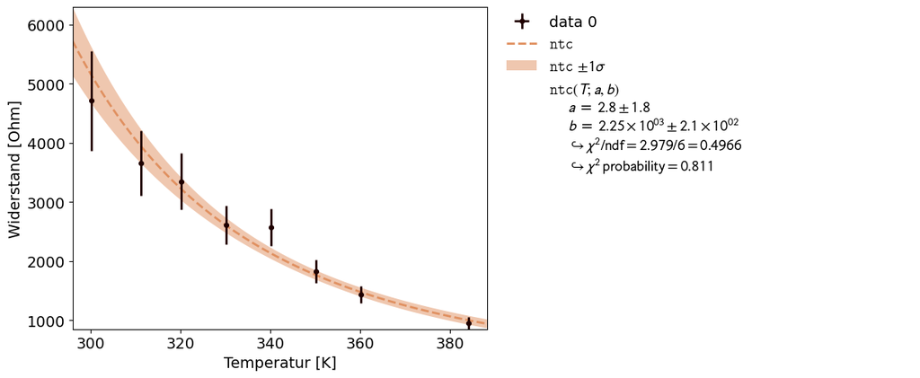

```python
NTC = np.array([[27,1750.0],[38,2145.0],[47,2300.0],[57,2770.0],[67,2800.0],[77,3540.0],[87,4110.0],[111,5135.0]])
NTC[:,0] += 273.15
R_NTC = (ufloat(10000,300)-unumpy.uarray(NTC[:,1],300))/unumpy.uarray(NTC[:,1],300)*ufloat(1000,10)

def ntc(T,a,b):
    return a*np.exp(b/T)


NTC_Cont = kafe2.XYContainer(NTC[:,0],unumpy.nominal_values(R_NTC))
NTC_Cont.add_error(axis='x',err_val=0.5)
NTC_Cont.add_error(axis='y',err_val=unumpy.std_devs(R_NTC))
NTC_Cont.axis_labels=['Temperatur [K]','Widerstand [Ohm]']

NTC_Fit = kafe2.Fit(NTC_Cont,ntc)
NTC_Fit.do_fit()

NTC_Plot = kafe2.Plot(NTC_Fit)
NTC_Plot.plot()
plt.show()
a=1
```

Damit bestätigt sich der Zusammenhang

$R_{NTC} = a\,e^{\frac{b}{T}}$ mit $a=2.8\pm1.8\,\Omega$ und $b = 2250\pm210\,K$

Die Messung für $T\approx340 K$ scheint sehr von der Erwartung durch die restlichen Werte abzuweichen. Dies ist vermutlich auf einen Messfehler durch den Fehlerhaften Aufbau/unserer Benutzung zu erklären.

Aufgrund der fehlerhaften funktionalität der Wheatsonschen Brücke haben wir uns bei der Messung für den PTC für einen einfachen Spannungsteiler entschieden. Hierzu schalteten wir einen einfachen $100 \Omega$-Widerstand in Reihe mit dem zu messenden PTC-Element.

Auf einfacher Überlegung folgt:

$U_{ges} = U_{PTC} + U_{100\Omega}$

$\frac{U_{100\Omega}}{R_{100\Omega}} = \frac{U_{PTC}}{R_{PTC}}$

$R_{PTC} = \frac{U_{100\Omega}}{U_{PTC}}R_{100\Omega}=\frac{U_{Ges}-U_{PTC}}{U_{PTC}}R_{100\Omega}=(\frac{U_{Ges}}{U_{PTC}}-1)R_{100\Omega}$

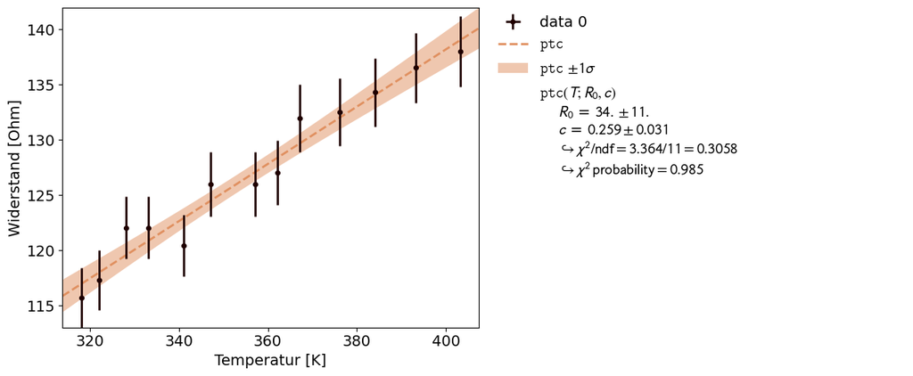

```python
PTC = np.array([[130,1.923,0.808],[120,1.923,0.813],[111,1.940,0.828],[103,1.923,0.827],[94,1.923,0.829],[89,1.923,0.847],[84,1.914,0.847],[74,1.923,0.851],[68,1.909,0.866],[60,1.923,0.866],[55,1.923,0.866],[49,1.923,0.885],[45,1.909,0.885]])
PTC[:,0] += 273.15
R_PTC = (unumpy.uarray(PTC[:,1],0.01)/unumpy.uarray(PTC[:,2],0.01)-1)*100

def ptc(T,R_0,c):
    return R_0+c*T

PTC_Cont = kafe2.XYContainer(PTC[:,0],unumpy.nominal_values(R_PTC))
PTC_Cont.add_error(axis='x',err_val=0.5)
PTC_Cont.add_error(axis='y',err_val=unumpy.std_devs(R_PTC))
PTC_Cont.axis_labels=['Temperatur [K]','Widerstand [Ohm]']

PTC_Fit = kafe2.Fit(PTC_Cont,ptc)
PTC_Fit.do_fit()

PTC_Plot = kafe2.Plot(PTC_Fit)
PTC_Plot.plot()
plt.show()
```

Wir erhalten einen linearen Zusammenhang von

$R_{PTC} = R_{0}+c\,T$, mit $R_{0}=34\pm11\,\Omega$ und $c=0.259\pm0.031\,\frac{\Omega}{K}$

Damit liegt der erwartete Widerstand bei $T = 0°C$:

$R_{PTC}(T=0) = 104\pm14\,\Omega$

was der Erwartung für den PTC entspricht

Auch durch die improvosierte Methode scheint sich der lineare Zusammenhang aus der Messung gut herzuleiten. Die relativ großen Fehler sind auf die ungenauigkeit des Oszilloskops und des Messverfahrens an sich zurückzuführen.

**Lösung:**

*Sie können Ihr Protokoll direkt in dieses Dokument einfügen. Wenn Sie dieses Dokument als Grundlage für ein [Jupyter notebook](https://jupyter.org/) verwenden wollen können Sie die Auswertung, Skripte und ggf. bildliche Darstellungen mit Hilfe von [python](https://www.python.org/) ebenfalls hier einfügen. Löschen Sie hierzu diesen kursiv gestellten Text aus dem Dokument.*

**Einsatzmöglichkeiten von NTC-Widerständen**

- Temperaturmessung: Dieser Einsatzbereich ist offensichtlich und ergibt sich aus der oben dargelegten, und der durch den Versuch bestimmten, Formel für den Zusammenhang von Widerstand und Temperatur.
- Füllstandsanzeige: Aufgrund der generell sehr hohen Temperaturleitfähigkeit von Flüssigkeiten im Vergleich zu Luft sorgen sie für eine starke Wärmeübertragung zwischen einem sich erhitzenden Bauteil und der Umgebung. Diese schnelle Wärmeübertragung kann nun durch den nur noch wenig stromabhängigen Widerstand bestimmt werden.

  Die Wärmeleistung, welche nach

  $P = U\,I = \frac{U^2}{R}$

  an den Widerstand abgegeben wird, wird also direkt an die Füssigkeit mit weitaus größerer Oberfläche und Wärmekapazität übertragen, wodurch sich der Widerstand nur noch schwach erhitzt.
- Strombegrenzung: Hierzu muss der NTC parallel zu dem zu schützenden Bauteil angebracht werden. Wird der Strom durch den NTC so stark, dass die nach

**Einsatzmöglichkeiten des PT100**

- Temperaturmessung: Aufgrund der nahäurngsweisen linearen Abhängigkeit des Widerstandes von der Temperatur, eignet es sich hervorragend hierzu

### Aufgabe 2: Kennlinien

Überlegen Sie sich zur Vorbereitung auf diesem Versuch Antworten zu den folgenden Fragen und fertigen Sie entsprechende Schaltskizzen an:

- Wie können Sie eine Spannungsstabilisierung mit Hilfe einer Zenerdiode realisieren?
- Wie können Sie den Varistor als Schutz gegen induzierte Spannungen an geschalteten Induktivitäten verwenden?

**Vorbereitende Überlegungen**:

Eine Zenerdiode könnte parralel zu einem Stromkreis/einem Bauteil eingesetzt werden, um bei zu hoher Spannung den Strom über sich selbst abzuleiten.

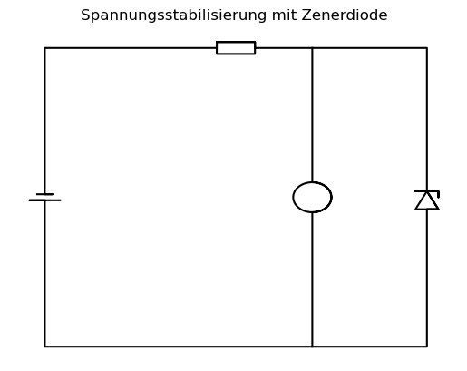

```python
draw_circuit()
```

Der Aufbau beim Varistor ist wieder ähnlich zu dem der Zehnerdiode. Parallel zur Spule geschalten sorgt er für die Abfuhr von zu hohen Spannungen über sich selbst.

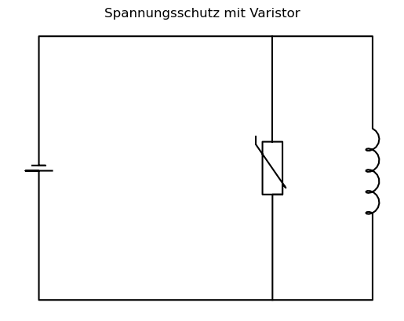

```python
draw_circuit2()
```

#### Aufgabe 2.1

Nehmen Sie die Kennlinien folgender Bauteile am USB-Oszilloskop auf:

- $\mathrm{Si}$-Diode (SID)
- $\mathrm{Ge}$-Diode (GED)
- Zener-Diode (ZED)
- Varistor (VDR)
- Fotodiode
- Fotowiderstand
- LED (in vier verschiedenen Farben).

Verwenden Sie dafür die Versuchsbox mit der folgenden Schaltskizze, an die Sie das Eingangssignal über den Trenntransformator in Form einer sinusförmigen Wechselspannung (mit der Frequenz $\nu=100\,\mathrm{Hz}$) angelegen: ([Link](https://git.scc.kit.edu/etp-lehre/p2-for-students/-/raw/main/Elektrische_Bauelemente/figures/Kennlinienaufnahme.jpg))

[figure not shown]

Gemäß der Schaltung werden über einem Widerstand (mit $R=100\,\Omega$) an Kanal A (CH A) und über dem jeweiligen Bauteil an Kanal B (CH B) Spannungen abgenommen. Mit Hilfe der XY-Darstellung der „PicoScope 6-Software“ kann dann die jeweilige Kennlinie aufgenommen werden. Untersuchen Sie hierbei insbesondere die folgenden Eigenschaften:

- Die SID, GED und ZED auf ihre jeweilige Schwellenspannung und ggf. auch Zenerspannung.
- Das Verhalten der Fotodiode bei verschiedenen Beleuchtungen (z.B. durch die Smartphone-Lampe).
- Das Verhalten des Fotowiderstands bei verschiedenen Beleuchtungen.
- Die Verschiedenfarbigen LEDs auf ihre jeweilige Schwellenspannung und den Zusammenhang mit der Frequenz des emittierten Lichts.

Interpretieren Sie die Kennlinien ausführlich und geben Sie charakteristische Punkte an. Berechnen Sie beim Fotowiderstand aus der Steigung der Kennlinien den jeweiligen Widerstandswert. Schließen Sie auf typische Eigenschaften der Bauteile und leiten Sie daraus mögliche Anwendungen ab.

Die Schaltung wurde gemäß der Aufgabenstellung aufgebaut. Bei den nachfolgend dargestellten Graphiken handelt es sich um Strom-Spannungs-Kennlinien. Dabe ist die Spannung auf der x-Achse und der Strom auf der y-Achse aufgetragen. Da die Masse beider Kanäle zusammengelegt werden musste sind die Werte an der x-Achse gespiegelt. Da der Strom durch den Spannungsabfall an einem $100\,\Omega$ Widerstand gemessen wurde ist die y-Achse nicht richtig skaliert und mus gemäß $I=\frac{U}{R}$ durch $100$ geteilt werden um Werte für den Strom zu erhalten.

[figure not shown]

Abb 2.1.1 Strom-Spannungs-Kennlinie einer Silizium Diode

Die Schwellspannung der Si-Diode betrug im Versuch $U_{Schwelle}\approx$ 670mV und liegt somit im zu erwartenden Bereich um ~$0.7\,V$ Sobald die Schwellspannung erreicht ist steigt der Strom steil an. Die Durchbruchsspannung wurde nicht erreicht.

[figure not shown]

Abb 2.1.2 Strom-Spannungs-Kennlinie einer Germanium Diode

Die Schwellspannung der Ge-Diode betrug im Versuch $U_{Schwelle}\approx$ 370mV. Dies war jedoch nicht eindeutig festzulegen da der Strom bei erreichen der Schwellspannug nicht so steil ansteigt wie bei der Si-Diode. Die Durchbruchsspannung wurde nicht erreicht.

[figure not shown]

Abb 2.1.3 Strom-Spannungs-Kennlinie einer Zener-Diode

Zener-Dioden sind höher dotierte Dioden. Im Vergleich zu einer herkömmlichen Diode ist die Durchbruchsspannunng einer Zener-Diode deutlich geringer. Das liegt daran, dass durch das in Sperrrichtung anliegende E-Feld Elektronen aus dem Gitter gerissen werden welche selbst weitere Elektronen mitreisen. Dadurch kommt es zum Durchbruch der Sperrschicht. Die notwendige Spannung wird als Zenerspannung bezeichnet und ist temperaturabhängig. Die gemessene Schwellspannung betrug $670\,mV$ die Durchbruchsspannung betrug $3.65\,V$. Es ist zu beachten, dass die x-Achse spiegelverkehrt ist weil die Diode in die andere Richtung eingebaut wurde. Die Schwellspannung ist links zu sehen und rechts die Zenerspannung.

[figure not shown]

Abb 2.1.4 Strom-Spannungs-Kennlinie eines Varistors

Der Varistor ist ein Spannungsabhängiger Widerstand. Er besteht aus zufällig angeordneten n-p-Übergängen. Durch die zufällige Anordnung ergibt sich eine Richtungsunabhängigkeit und somit eine symmetrische Strom-Spannungs-Kennlinie. Je höher die anliegende Spannung ist desto mehr Sperrschichten werden abgebaut und desto geringer der Widerstand. Für die Spannung wurde $U_V=10\,V$ gemessen.

Die Strom-Spannungs-Kennlinie einer Led ist vergleichbar zu der einer normalen Diode. Dabei unterscheiden sich die Dioden nur in der Schwellspannung. Die Schwellspannung ist nimmt dabei mit steigender Wellenlänge ab und betrug:

$U_{\rm{s,grün}} = 1.80\,V$

$U_{\rm{s,gelb}} = 1.78\,V$

$U_{\rm{s,orange}} = 1.6\,V$

$U_{\rm{s,rot}} = 1.57\,V$

Da kleinere Wellenlängen höhere Energien besitzen und damit der Abstand der Bänder größer ist werden höhere Spannungen benötigt.

[figure not shown]

Abb 2.1.5 Strom-Spannungs-Kennlinie einer grünen Led

[figure not shown]

Abb 2.1.6 Strom-Spannungs-Kennlinie einer gelben Led

[figure not shown]

Abb 2.1.7 Strom-Spannungs-Kennlinie einer orangen Led

[figure not shown]

Abb 2.1.8 Strom-Spannungs-Kennlinie einer roten led

[figure not shown]

Abb 2.1.9 Strom-Spannungs-Kennlinie einer beleuchteten Photodiode

[figure not shown]

Abb 2.1.10 Strom-Spannungs-Kennlinie einer unbeleuchteten Photodiode

Bei der Photodiode wurde die Schwellspannung nicht aufgenommen da sie für den Betrieb nicht relevant ist. Eine Photodiode wird in Sperrrichtung verbaut. Durch Bestrahlung entstehen Elektron-Loch-Paare, dadurch wird Strom geleitet. Der Strom ist dabei abhängig von der Intensität der Bestrahlung. Im Versuch Steigt die Spannung am Widerstand bei Beleuchtung der Diode auf $20\,mV$ es fließen also $0.2\,mA$

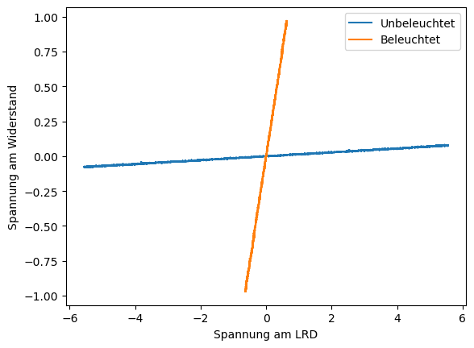

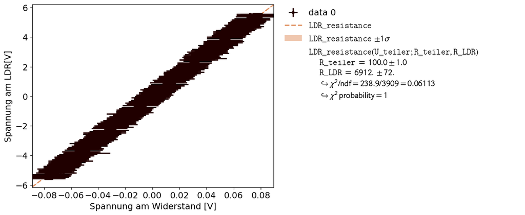

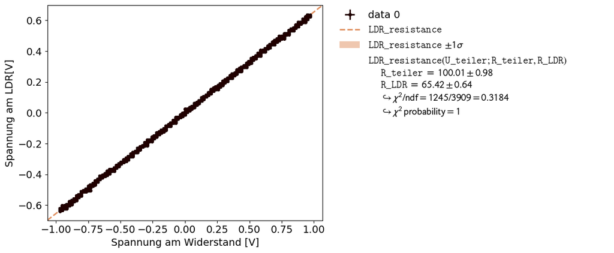

```python
LDR_ohne = pd.read_csv("E-bauelemente\LDR-ohneLicht.csv" ,delimiter=";",decimal=",")
LDR_mit = pd.read_csv("E-bauelemente\LDR-mitLicht_01.csv",delimiter=";",decimal=",")

plt.plot(LDR_ohne['Kanal B(V)'],-LDR_ohne['Kanal A(mV)']/1000,label="Unbeleuchtet")
plt.plot(LDR_mit['Kanal B(V)'],-LDR_mit['Kanal A(V)'],label="Beleuchtet")
plt.legend()
plt.ylabel("Spannung am Widerstand")
plt.xlabel("Spannung am LRD")
plt.show();


def LDR_resistance(U_teiler,R_teiler,R_LDR):
    return R_LDR*(U_teiler/R_teiler)




LDR_Cont = kafe2.XYContainer(-LDR_ohne['Kanal A(mV)']/1000,LDR_ohne['Kanal B(V)'])
LDR_Cont.add_error(axis='x',err_val=0.01)
LDR_Cont.add_error(axis='y',err_val=0.01)
LDR_Cont.axis_labels=['Spannung am Widerstand [V]','Spannung am LDR[V]']

LDR_Fit = kafe2.Fit(LDR_Cont,LDR_resistance)
LDR_Fit.add_parameter_constraint(name="R_teiler",value=100,uncertainty=1)
LDR_Fit.do_fit()

LDR_Plot = kafe2.Plot(LDR_Fit)
LDR_Plot.plot()

LDR_Cont_bel = kafe2.XYContainer(-LDR_mit['Kanal A(V)'],LDR_mit['Kanal B(V)'])
LDR_Cont_bel.add_error(axis='x',err_val=0.01)
LDR_Cont_bel.add_error(axis='y',err_val=0.01)
LDR_Cont_bel.axis_labels=['Spannung am Widerstand [V]','Spannung am LDR[V]']

LDR_Fit_bel = kafe2.Fit(LDR_Cont_bel,LDR_resistance)
LDR_Fit_bel.add_parameter_constraint(name="R_teiler",value=100,uncertainty=1)
LDR_Fit_bel.do_fit()

LDR_Plot_bel = kafe2.Plot(LDR_Fit_bel)
LDR_Plot_bel.plot()
plt.show()
```

#### Aufgabe 2.2

Untersuchen Sie qualitativ die Frequenzabhängigkeit einiger Bauelemente bei Frequenzen von $\nu=0,1\,\mathrm{kHz}$ bis $10\,\mathrm{kHz}$).

[figure not shown]

Abb 2.2.1 Strom-Spannungs-Kennlinie einer Si-Diode bei $10\,kHz$

Es ist zu erkennen das unterhalb der Schwellspannung auch ein kleiner Strom fließen kann. Bei hohen Frequenzen findet das Aufweiten und verschmälern der Verarmungszone nichtmehr schnell genug statt. Die Sperrschicht wird nicht vollständig aufgebaut und so bleibt die Diode länger leitfähig.

[figure not shown]

Abb 2.2.2 Strom-Spannungs-Kennlinie eines Varistors bei $10\,kHz$

Beim Varistor sin ähnliche Effekte wie bei der Diode zu beobachten. Auch hier kommt es zu Verzögerungen beim auf und Abbau der Sperrschichten, so kommt es bei hohen Frequenzen dazu dass Sich eine kreisförmige/ovale Kennlinie bildet. Interessante Effekte treten um $500\,Hz$ auf. Hier lässt sich die Hysteresekurve nicht so einfach erklären. Es kommt zu Kringeln. In allen Fällen bleibt die Kurve jedoch symetrisch.

[figure not shown]

Abb 2.2.3 Strom-Spannungs-Kennlinie eines Varistors bei $500\,Hz$

### Aufgabe 3

Nehmen Sie die Kennlinie einer Fotodiode bei verschiedenen Beleuchtungsstärken auf und entnehmen Sie dieser jeweils den Sperrstrom. Verwenden Sie hierzu die Schaltung aus Aufgabe 2 aus bei $\nu=10\,\mathrm{Hz}$, sowie die regulierbare Experimentierleuchte mit Fotodioden-Aufsatz. Beginnen Sie bei einer Lampenspannung von $U=2\,\mathrm{V}$ als niedrigste Stufe der Beleuchtung und beobachten Sie die Veränderung der Kennlinie bei zunehmender Spannung (in Schritten von $1\,\mathrm{V}$) und Beleuchtungsstärke. Stellen Sie in der Auswertung den Zusammenhang zwischen Sperrstrom und Beleuchtungsstärke graphisch dar.

Hinweis: Die Umrechnungstabelle zwischen Lampenspannung und Beleuchtungsstärke finden Sie unter [`params/Umrechnung_Lampenspannung.csv`.](https://git.scc.kit.edu/etp-lehre/p2-for-students/-/blob/main/Elektrische_Bauelemente/params/Umrechnung_Lampenspannung.csv)

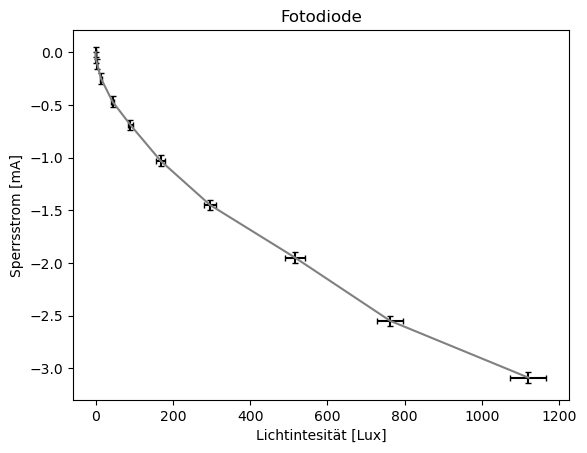

```python
belichtete_diode = np.array([[2,0],[3,-0.005],[4,-0.011],[5,-0.025],[6,-0.047],[7,-0.069],[8,-0.103],[9,-0.145],[10,-0.195],[11,-0.255],[12,-0.309]])
R = 100
umrechnung = pd.read_csv('params/Umrechnung_Lampenspannung.csv')
umrechnung['factor'] = umrechnung['E (lux)']/umrechnung['U (V)']
errx = 0.5*umrechnung['factor'][2:13]
x_val = belichtete_diode[:,0]*umrechnung['factor'][2:13]
plt.errorbar(x_val,belichtete_diode[:,1]/R*1000,0.005/R*1000,errx,color='grey',ecolor='black',capsize=2)
plt.title('Fotodiode')
plt.ylabel('Sperrsstrom [mA]')
plt.xlabel('Lichtintesität [Lux]')
plt.show()
```

### Aufgabe 4: Piezoelektrischer Effekt

Untersuchen Sie den piezoelektrischen Effekt am Piezoelement. Gehen Sie dabei wie folgt vor:

- Beobachten Sie den direkten piezoelektrischen Effekt am USB-Oszilloskop, indem Sie manuell verschiedene Drücke auf das Piezoelement ausüben. Machen Sie ein Frequenzsignal sichtbar, indem Sie mit dem Frequenzgenerator verschiedene Signale auf den Lautsprecher geben und diese auf das Piezoelement übertragen.
- Überprüfen Sie die Funktion des Piezoelements als Lautsprecher. Schließen Sie es hierzu direkt an den Frequenzgenerator an.
- Beschreiben Sie Ihre Beobachtungen und diskutieren Sie Anwendungen des piezoelektrischen Effekts.

Bei Piezokristallen handelt es sich um Kristalle aus positiv und negativ geladenen Ionen. Wird nun Druck ausgeübt kommt wes zur Verschiebung der ungleichnamigen Ladungsträger gegeneinander und so zu einer Spannung. Wird umgekehrt eine Spannung angelegt so verschieben sich die Ionen und es kommt zur Kontraktion.

Wurde das Piezoelement direkt ans Oszilloskop angeschlossen und belastet ließen sich Ausschläge der Spannung beobachten. Anschließend wurde ein Lautsprecher an den Frequenzgenerator angeschlossen und eine Frequenz von $440\,Hz$ erzeugt und mit dem Piezoelement gemessen. Zu sehen ist das $440\,Hz$ Signal und ein zweites niederfrequentes Signal. Die Vermutung liegt nahe, dass es sich hier umm die Netzfrequenz mit $50\,Hz$ handelt, auch wenn zum Anschluss des Lautsprechers nicht der Transformator verwendet wurde.

[figure not shown]

Abb 4.1 $440\,Hz$ Signal eines Lautsprechers gemessen durch den Piezoeffekt

Als das Piezo-element an den Frequenzgenerator angeschlossen wurde, konnte ein Ton ab ~ $1\,kHz$ wahrgenommen werden, jedoch ließ sich dieser mit dem am Oszilloskop angeschlossenen Lautsprecher nicht aufnehmen. Tiefere Töne ließen sich aufgrund des beschädigten Elementes nicht erzeugen.

Piezoelemente werden als Lautsprecher/Summer verwendet. Genauso lassen sie sich als Mikrophone oder Tonabnehmer(besser da belastet) verwenden oder zur Schwingungsmessung (z.B. Schwingungen im Boden) einsetzen. Sie werden ebenso zur Feinpositionierung verwendet.

### Aufgabe 5: Hochtemperatursupraleiter

Bestimmen Sie die Sprungtemperatur eines Hochtemperatursupraleiters. Gehen Sie dabei wie folgt vor:

Messen Sie den Spannungsabfall am Hochtemperatursupraleiter mit Hilfe der fertig aufgebauten Vierleiterschaltung ($I_\mathrm{const}=63\,\mathrm{mA}$) und des Multimeters. Kühlen Sie die Probe von Raumtemperatur auf $T=77\,\mathrm{K}$ ab. Nutzen Sie hierfür den Temperaturgradienten über dem Stickstoff-Bad. Nehmen Sie eine Messreihe aus $U_{\mathrm{gem}}$ und zugehöriger Temperatur $T$ (in Schritten von $5\,\mathrm{K}$) auf. Beschreiben Sie das Verhalten des Hochtemperatursupraleiters.

- Tragen Sie zur Auswertung den Widerstand $R=U_{\mathrm{gem}}/I$ über der Temperatur $T$ auf und geben Sie die Sprungtemperatur an.
- Erklären Sie, warum zur Messung eine Vierleiterschaltung verwendet wird.

Beachten Sie, dass die Anzeige des Thermometers bei tiefen Temperaturen entsprechend der im Datenblatt angegebenen Tabelle [`params/Temperatur_Korrektur.csv`](https://git.scc.kit.edu/etp-lehre/p2-for-students/-/blob/main/Elektrische_Bauelemente/params/Temperatur_Korrektur.csv) vom wahren Wert abweicht. Für die Beurteilung der Sprungtemperatur beachten Sie, dass am Ort von Temperatursensor und Supraleiter ein hoher Temperaturgradient vorliegt.

[figure not shown]

```python
I = 0.063 #A

supra = np.array([[24,0.0013],[20,0.001285],[10,0.001255],[0,0.001211],[-5,0.001195],[-10,0.001175],[-15,0.001156],[-20,0.001138],[-25,0.001120],[-30,0.001101],[-35,0.001083],[-40,0.001064],[-45,0.001045],[-50,0.001026],[-55,0.001009],[-60,0.000992],[-65,0.000975],[-70,0.000956],[-75,0.000939],[-80,0.000921],[-85,0.000903],[-90,0.000882],[-95,0.000864],[-100,0.000845],[-105,0.000819],[-110,0.000794],[-115,0.000767],[-116,0.000762],[-117,0.000757],[-118,0.000752],[-119,0.000746],[-120,0.000739],[-121,0.000732],[-122,0.000726],[-123,0.000720],[-124,0.000714],[-126,0.000697],[-127,0.000689],[-128,0.000680],[-129,0.000510],[-130,0.000360],[-131,0.000285],[-132,0.000238],[-133,0.000218],[-133.5,0.000218],[-134.5,0.000189],[-135,0.000160],[-135.5,0.000136],[-136,0.000120],[-136.5,0.000109],[-137,0.000095],[-137.5,0.000082],[-138,0.000066],[-138.5,0.000054],[-139,0.000040],[-139.5,0.000035],[-140,0.000025],[-140.3,0.000021],[-140.5,0.000019],[-140.7,0.000015],[-141,0.000013],[-141.1,0.000011],[-141.2,0.000009],[-141.3,0.000007],[-141.4,0.000005],[-141.6,0.000002],[-141.8,0]])

#Tabelle mit richtigen faktoren importieren
Tempcorr = pd.read_csv('params/Temperatur_Korrektur.csv')
Tempcorr['faktor'] = Tempcorr['Temperatur (°C)']/Tempcorr['Anzeige (°C)']
Tempcorr

#Daten an die korrektur aus der Messtabelle anpassen
def correct(data):
    for loc,element in enumerate(data):
        for ref in Tempcorr['Anzeige (°C)']:
            if abs(element-ref)<2.5:
                data[loc] *= Tempcorr['faktor'][Tempcorr['Anzeige (°C)']==ref].values[0]
correct(supra[:,0])

#Daten plotten
supra[:,0] += 273.15
supra[:,1] *= 1000/I
plt.axvline(x=145.44470453, color='red', linestyle='--', label='Sprungtemperatur [145.4$\pm$0.5 K]')
plt.axvline(x=131.38, color='green', linestyle='--', label='Supraleitende Temperatur [131.8$\pm$0.5 K]')
plt.errorbar(supra[:,0],supra[:,1],0.2,xerr=0.5,ecolor='black',color='grey')
plt.xlabel('Temperatur [K]')
plt.ylabel('Widerstand [mOhm]')
plt.legend()
plt.show()
```

Für die Messung wurde eine Vierleiterschaltung verwendet, da diese relativ Temperaturstabil ist. Dadurch, dass zwei Widerstände zwischen Supraleiter und Quelle, sowie Supraleiter und Multimeter angebracht sind, wirkt sich eine änderung der Referenzwiderstände durch Temperatur allgemein fast nicht auf die Messung aus, da diese Änderung kompensiert wird.